# Bloomingdales Data Analysis

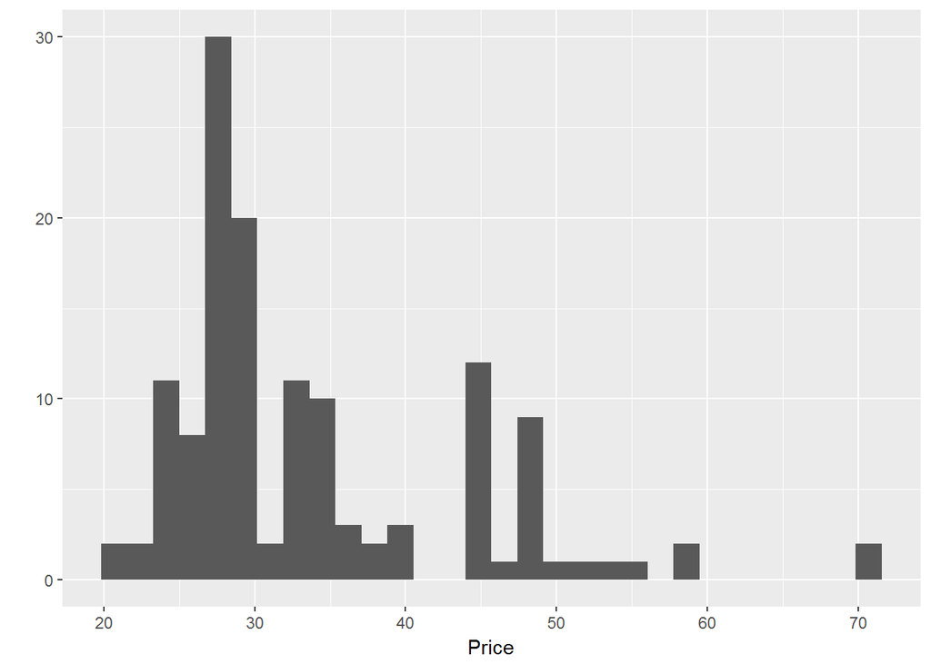

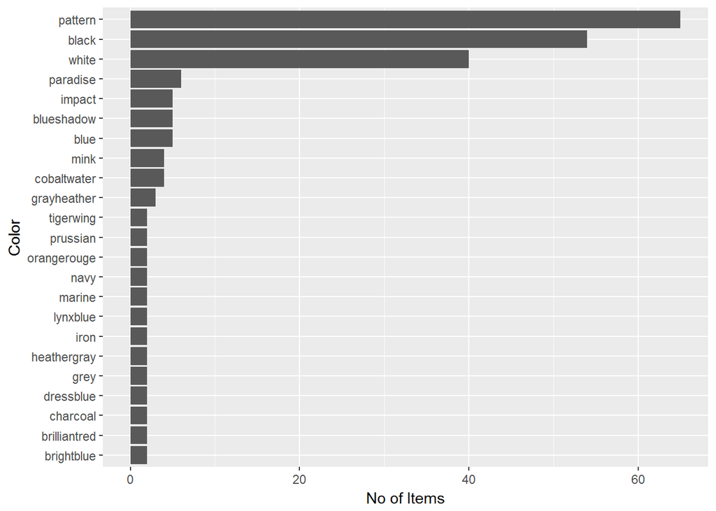

Box plots of prices by color. Average is the same for all - not surprisingly. However, there are definitely more examples of higher priced pattern underwear.

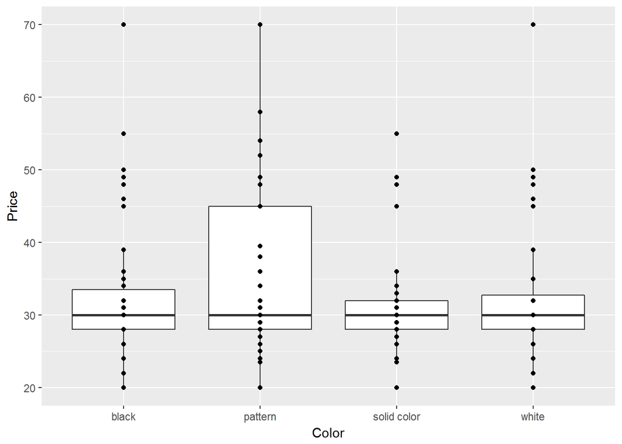

Box plots by material. It may be worthwhile to look into polyamide. Keep in mind that there are very few products that use it, but the prices seem to be higher.

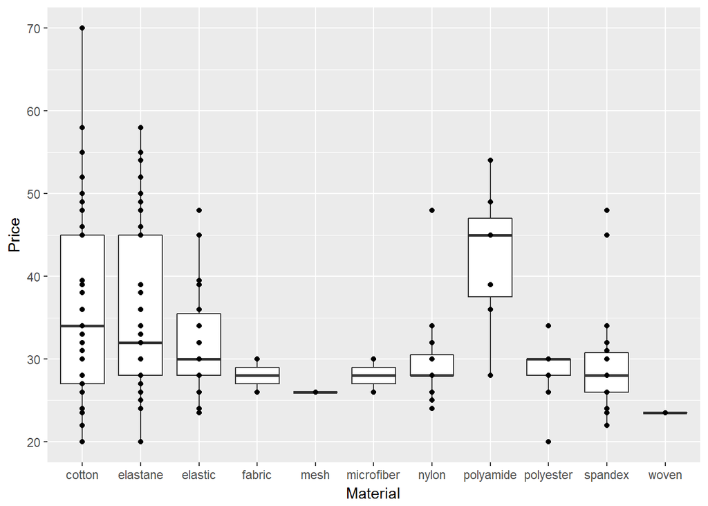

Box plots by type of underwear. It may appear that boxers are priced higher than other types, but there are very few products offered and the spread is pretty wide. I believe boxers are just not as popular as other types.

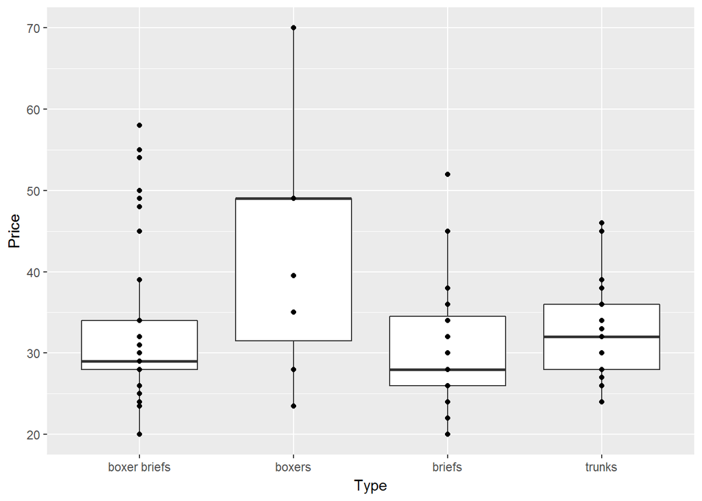

Tile plot of material by type. Darker rectangle is less products of that type and material.

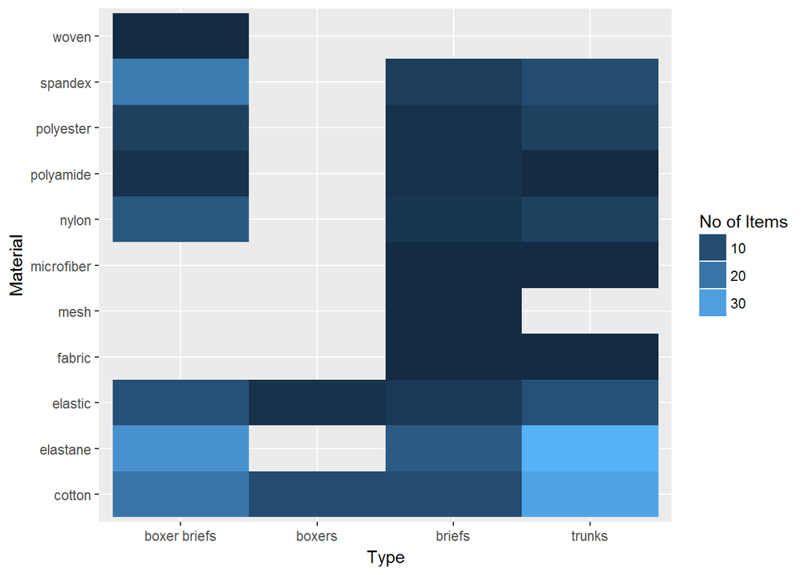

Box plots by number of colors offered. The average is about the same for all.

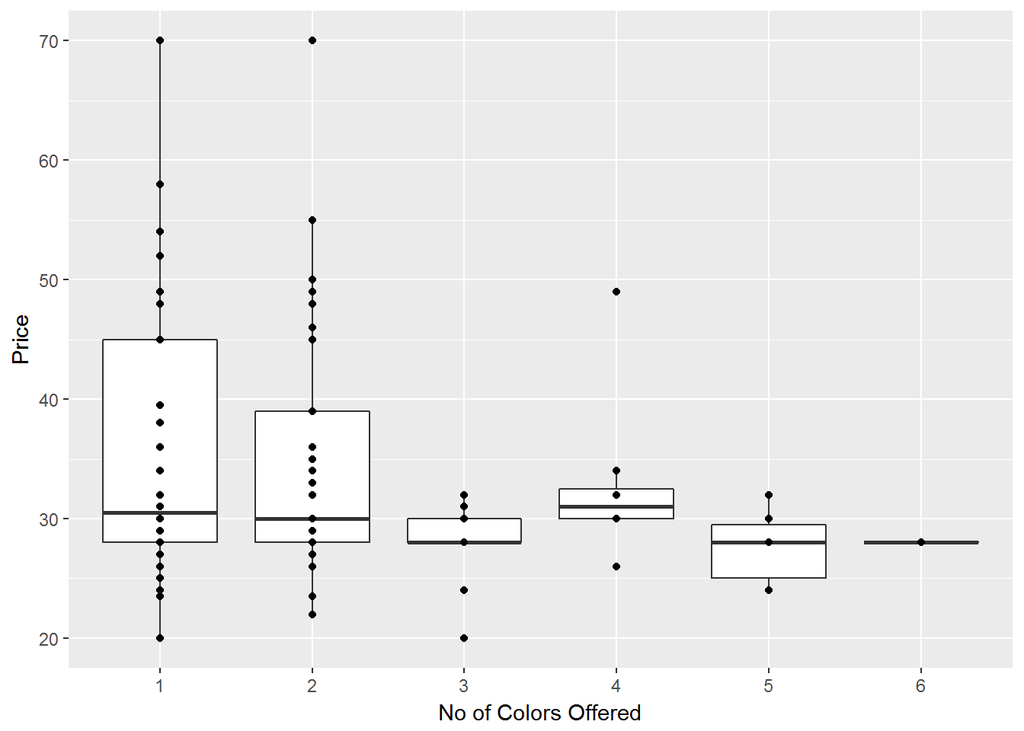